# include additional mm4 human data to correct batch effect

Sidney Wang

October 17, 2015

Since most of rhesus and chimp are in mm4, while the human data include in this study are not, batch order is to some degree confounded with species. To correct for bach effect, we decided to first include the additional 4 human data from mm4 to regress out batch effect and then proceed with analysis on the original set of 16 samples. The analysis in this document will assess the validity of this approach.

I went back to process additional data. The file “process_additional_human_data_from_mm4_101515” documented detailed description on the process. I then save the data table as r object in the rdr folder

load data

```r
load("../rdas/HRC.plus.mm4H.ribo.rda")
load("../rdas/mm4.ribo.rda")
load("../rdas/HCR.ortho.geneLength.rda")
```

plot count range

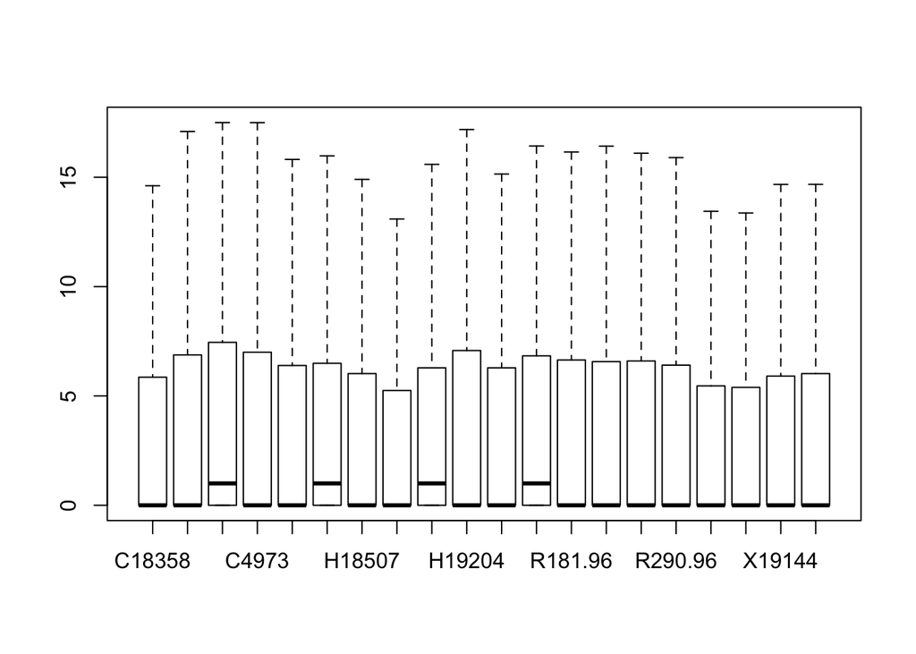

```r
boxplot(log2(HRC.plus.mm4H.ribo[,-1]+1), outline =F)
```

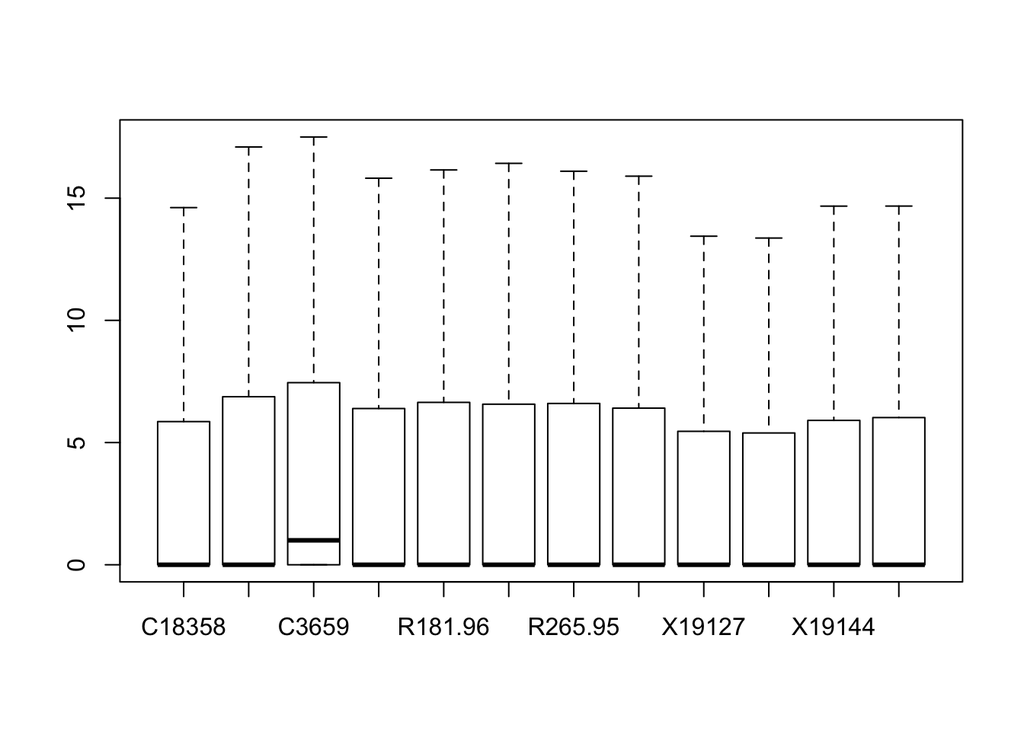

```r
boxplot(log2(mm4.ribo[,-1]+1), outline =F)
```

# compute RPKM

use human gene length

```r
HRC.plus.mm4H.rpkm.hLength <- prop.table(as.matrix(HRC.plus.mm4H.ribo[,-1]),2)*10^9/HCR.geneLength$Human

mm4.rpkm.hLength <- prop.table(as.matrix(mm4.ribo[,-1]),2)*10^9/HCR.geneLength$Human
```

use max gene length

```r
HRC.plus.mm4H.rpkm.maxLength <- prop.table(as.matrix(HRC.plus.mm4H.ribo[,-1]),2)*10^9/HCR.geneLength$HCR.max

mm4.rpkm.maxLength <- prop.table(as.matrix(mm4.ribo[,-1]),2)*10^9/HCR.geneLength$HCR.max
```

use species specific length

```r
HRC.plus.mm4H.rpkm.speLength <- prop.table(as.matrix(HRC.plus.mm4H.ribo[,-1]),2)*10^9
HRC.plus.mm4H.rpkm.speLength <- cbind(HRC.plus.mm4H.rpkm.speLength[,1:5]/HCR.geneLength$Chimp,HRC.plus.mm4H.rpkm.speLength[,6:11]/HCR.geneLength$Human,HRC.plus.mm4H.rpkm.speLength[,12:16]/HCR.geneLength$Rhesus,HRC.plus.mm4H.rpkm.speLength[,17:20]/HCR.geneLength$Human)


mm4.rpkm.speLength <- prop.table(as.matrix(mm4.ribo[,-1]),2)*10^9
mm4.rpkm.speLength<-cbind(mm4.rpkm.speLength[,1:4]/HCR.geneLength$Chimp, mm4.rpkm.speLength[,5:8]/HCR.geneLength$Rhesus, mm4.rpkm.speLength[,9:12]/HCR.geneLength$Human)
```

filter data by requiring at least half of mm4 data have rpkm greater than 0

```r
rpkm.filter<-c()
for (i in 1:length(mm4.rpkm.speLength[,1])){
rpkm.filter[i]<-sum(mm4.rpkm.speLength[i,] == 0) < 7
}

HRC.plus.mm4H.rpkm.speLength<-HRC.plus.mm4H.rpkm.speLength[rpkm.filter,]
mm4.rpkm.speLength<-mm4.rpkm.speLength[rpkm.filter,]
```

quantile normalize and log2 transform data

```r
library(limma)
HRC.plus.mm4H.rpkm.speLength.Q<-normalizeQuantiles(HRC.plus.mm4H.rpkm.speLength,ties = T)
mm4.rpkm.speLength.Q<-normalizeQuantiles(mm4.rpkm.speLength,ties = T)
log2.HRC.plus.mm4H.rpkm.speLength.Q<-log2(HRC.plus.mm4H.rpkm.speLength.Q)
is.na(log2.HRC.plus.mm4H.rpkm.speLength.Q)<-is.infinite(log2.HRC.plus.mm4H.rpkm.speLength.Q)
log2.mm4.rpkm.speLength.Q<-log2(mm4.rpkm.speLength.Q)
is.na(log2.mm4.rpkm.speLength.Q)<-is.infinite(log2.mm4.rpkm.speLength.Q)
```

DE test, LRT

```r
species.label<-as.factor(substring(colnames(log2.mm4.rpkm.speLength.Q),1,1))
CRpvalue<-c()
for (i in 1:length(log2.mm4.rpkm.speLength.Q[,1])){
fullModel<-lm(log2.mm4.rpkm.speLength.Q[i,1:8]~species.label[1:8])
reducedModel<-lm(log2.mm4.rpkm.speLength.Q[i,1:8]~1)
CRpvalue[i]<-anova(fullModel,reducedModel)$"Pr(>F)"[2]
}

HRpvalue<-c()
for (i in 1:length(log2.mm4.rpkm.speLength.Q[,1])){
fullModel<-lm(log2.mm4.rpkm.speLength.Q[i,5:12]~species.label[5:12])
reducedModel<-lm(log2.mm4.rpkm.speLength.Q[i,5:12]~1)
HRpvalue[i]<-anova(fullModel,reducedModel)$"Pr(>F)"[2]
}

HCpvalue<-c()
for (i in 1:length(log2.mm4.rpkm.speLength.Q[,1])){
fullModel<-lm(log2.mm4.rpkm.speLength.Q[i,-5:-8]~species.label[-5:-8])
reducedModel<-lm(log2.mm4.rpkm.speLength.Q[i,-5:-8]~1)
HCpvalue[i]<-anova(fullModel,reducedModel)$"Pr(>F)"[2]
}
```

qvalue

```r
library(qvalue)
qvalue(HCpvalue)$pi0
```

```
## [1] 0.4232477
```

```r
qvalue(CRpvalue)$pi0
```

```
## [1] 0.4321775
```

```r
qvalue(HRpvalue)$pi0
```

```
## [1] 0.3765623
```

```r
length(which(qvalue(HCpvalue)$qvalues < 0.01))
```

```
## [1] 488
```

```r
length(which(qvalue(HRpvalue)$qvalues < 0.01))
```

```
## [1] 2869
```

```r
length(which(qvalue(CRpvalue)$qvalues < 0.01))
```

```
## [1] 1329
```

DE test, beta

```r
species.label<-as.factor(substring(colnames(log2.mm4.rpkm.speLength.Q),1,1))
CRpvalue<-c()
CR.effect <- c()
CR.se<-c()
for (i in 1:length(log2.mm4.rpkm.speLength.Q[,1])){
fullModel<-lm(log2.mm4.rpkm.speLength.Q[i,1:8]~species.label[1:8])
CRpvalue[i]<-summary(fullModel)$coefficients[2,4]
CR.effect[i] <- summary(fullModel)$coefficients[2,1]
CR.se[i] <- summary(fullModel)$coefficients[2,2]

}

HRpvalue<-c()
HR.effect <- c()
HR.se <- c()

for (i in 1:length(log2.mm4.rpkm.speLength.Q[,1])){
fullModel<-lm(log2.mm4.rpkm.speLength.Q[i,5:12]~species.label[5:12])
HRpvalue[i]<-summary(fullModel)$coefficients[2,4]
HR.effect[i] <- summary(fullModel)$coefficients[2,1]
HR.se[i] <- summary(fullModel)$coefficients[2,2]

}

HCpvalue<-c()
HC.effect <- c()
HC.se <- c()

for (i in 1:length(log2.mm4.rpkm.speLength.Q[,1])){
fullModel<-lm(log2.mm4.rpkm.speLength.Q[i,-5:-8]~species.label[-5:-8])
HCpvalue[i]<-summary(fullModel)$coefficients[2,4]
HC.effect[i] <- summary(fullModel)$coefficients[2,1]
HC.se[i] <- summary(fullModel)$coefficients[2,2]

}
```

effect size and variance

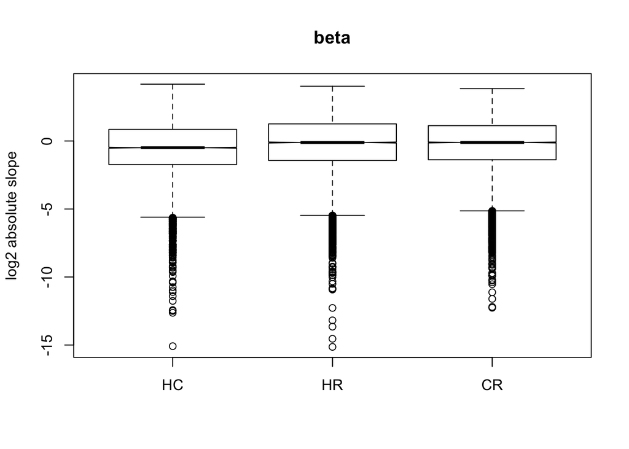

```r
boxplot(log2(abs(HC.effect)),log2(abs(HR.effect)),log2(abs(CR.effect)), xlab="",main="beta",ylab="log2 absolute slope", notch=T)
axis(1,at = c(1,2,3),labels = c("HC","HR","CR"))
```

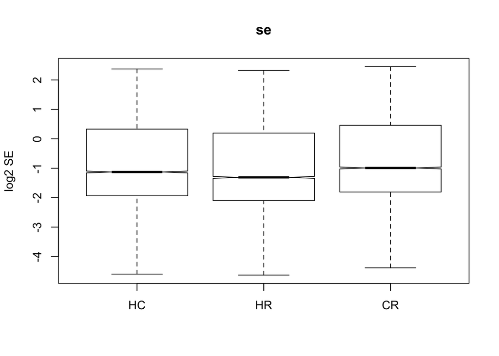

```r
boxplot(log2(HC.se),log2(HR.se),log2(CR.se), xlab="",main="se",ylab="log2 SE", notch=T)
axis(1,at = c(1,2,3),labels = c("HC","HR","CR"))
```

pca

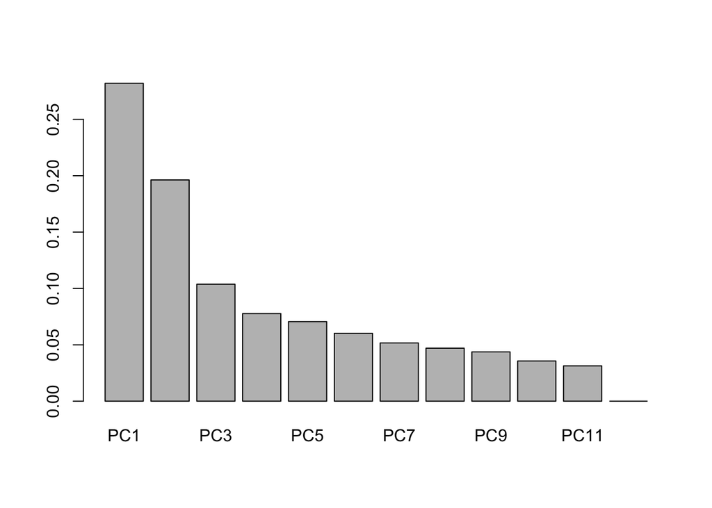

```r
library(ggplot2)
library(reshape2)
library(dplyr)
library(gdata)
pc<-prcomp(t(na.omit(log2.mm4.rpkm.speLength.Q)),center = T,scale = T)
barplot((pc$sdev)^2/sum((pc$sdev)^2), names.arg =  colnames(pc$x))
```

```r
spec<-substring(rownames(pc$x),1,1)
temp.data<-as.data.frame(cbind(melt(pc$x),pc$x[,1],spec))
```

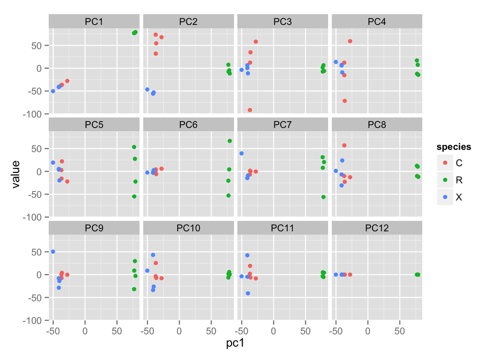

```r
names(temp.data)<-c("ID","PC","value","pc1","species")

temp.data %>% ggplot(aes(x=pc1,y=value))+geom_point(aes(color = species))+facet_wrap(~PC)
```

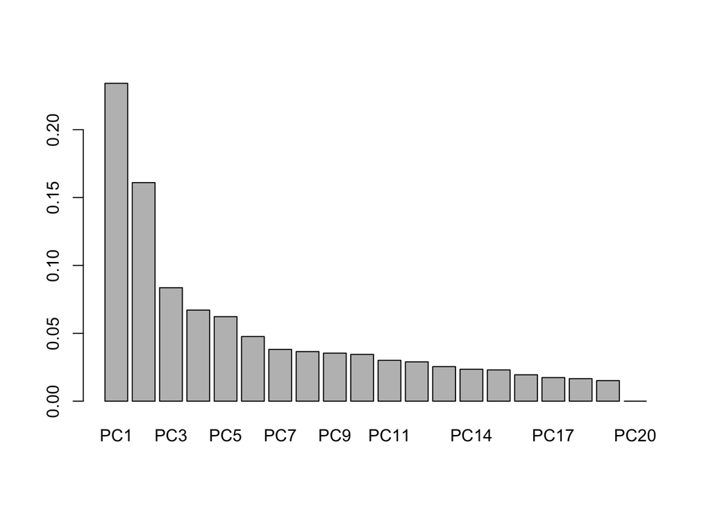

```r
read.xls("/Users/siddisis/Dropbox/work/Ribosome_profiling/Primate_comparison/primate_ribo_gender_mmbatch.xlsx")->cell.source
cell.source<-cell.source[,1:4]


batch<-c(as.character(cell.source$libmix),rep("mm4",4))

pc<-prcomp(t(na.omit(log2.HRC.plus.mm4H.rpkm.speLength.Q)),center = T,scale = T)
barplot((pc$sdev)^2/sum((pc$sdev)^2), names.arg =  colnames(pc$x))
```

```r
spec<-substring(rownames(pc$x),1,1)
temp.data<-as.data.frame(cbind(melt(pc$x),pc$x[,1],spec,batch))
```

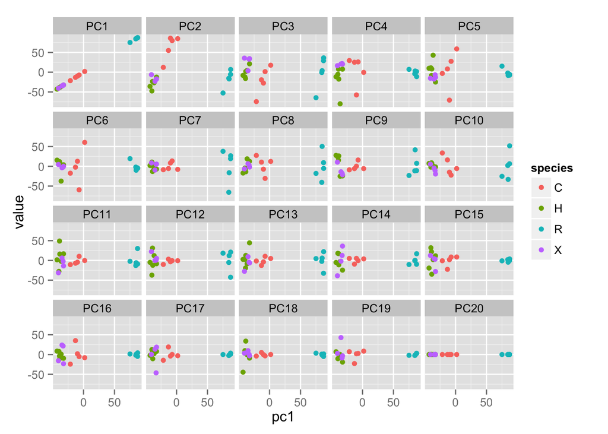

```r
names(temp.data)<-c("ID","PC","value","pc1","species","batch")

temp.data %>% ggplot(aes(x=pc1,y=value))+geom_point(aes(color = species))+facet_wrap(~PC)
```

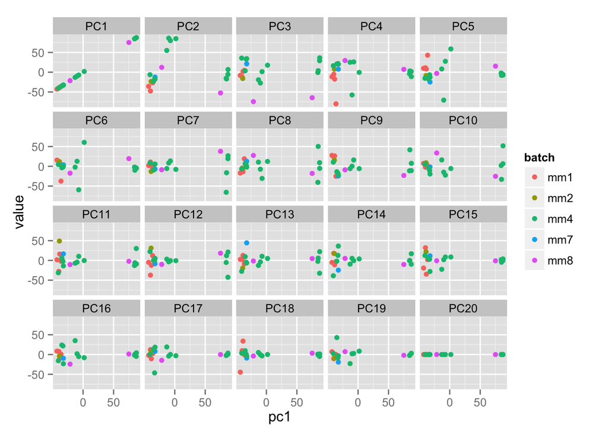

```r
temp.data %>% ggplot(aes(x=pc1,y=value))+geom_point(aes(color = batch))+facet_wrap(~PC)
```

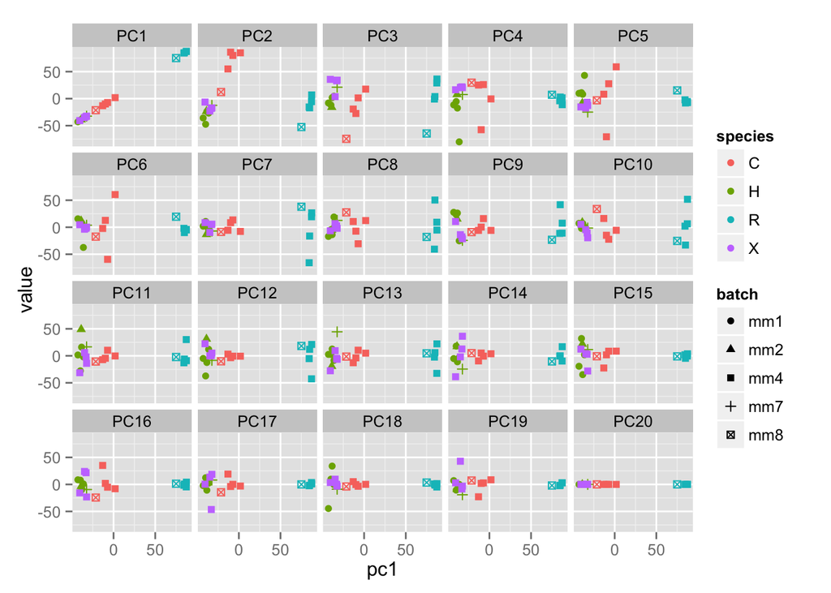

```r
temp.data %>% ggplot(aes(x=pc1,y=value))+geom_point(aes(color = species, shape = batch))+facet_wrap(~PC)
```

within speceis SD

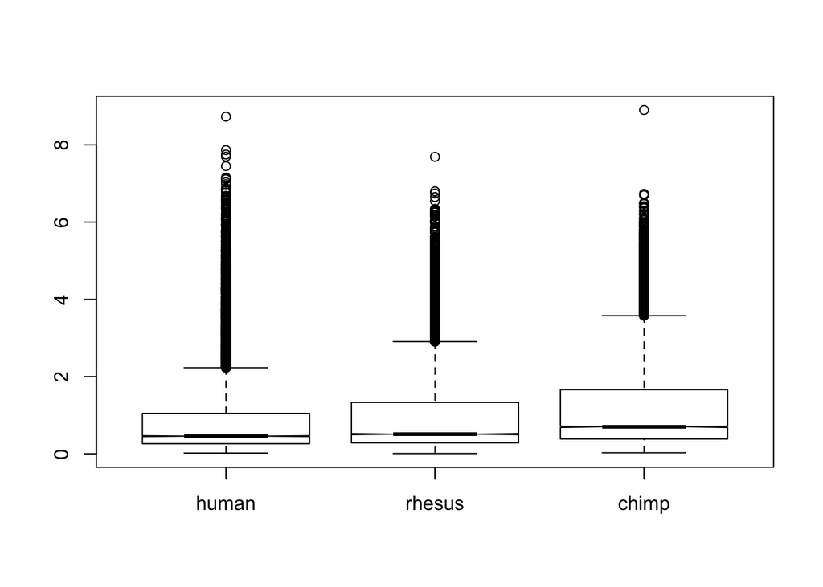

```r
SD.ribo.H<-apply(log2.mm4.rpkm.speLength.Q[,9:12], 1,sd,na.rm = T)
mean.ribo.H<-apply(log2.mm4.rpkm.speLength.Q[,9:12], 1,mean,na.rm = T)
SD.ribo.R<-apply(log2.mm4.rpkm.speLength.Q[,5:8], 1,sd,na.rm = T)
mean.ribo.R<-apply(log2.mm4.rpkm.speLength.Q[,5:8], 1,mean,na.rm = T)
SD.ribo.C<-apply(log2.mm4.rpkm.speLength.Q[,1:4], 1,sd,na.rm = T)
mean.ribo.C<-apply(log2.mm4.rpkm.speLength.Q[,1:4], 1,mean,na.rm = T)

CV.ribo.H <- SD.ribo.H - mean.ribo.H
CV.ribo.R <- SD.ribo.R - mean.ribo.R
CV.ribo.C <- SD.ribo.C - mean.ribo.C

boxplot(SD.ribo.H,SD.ribo.R,SD.ribo.C,xlab="", notch=T)
axis(1,c(1,2,3),c("human","rhesus","chimp"))
```

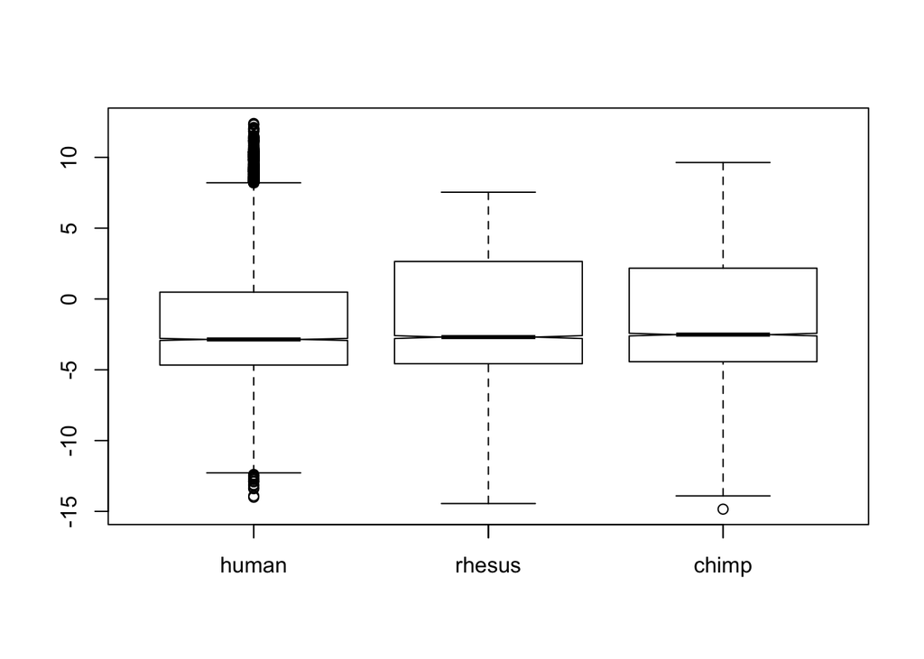

```r
boxplot(CV.ribo.H,CV.ribo.R,CV.ribo.C,xlab="", notch=T)
axis(1,c(1,2,3),c("human","rhesus","chimp"))
```

weighted least squared

```r
Var.ribo.R <- SD.ribo.R^2
Var.ribo.C <- SD.ribo.C^2
Var.ribo.H <- SD.ribo.H^2
species.label<-as.factor(substring(colnames(log2.mm4.rpkm.speLength.Q),1,1))
CRpvalue.weighted.var<-c()
for (i in 1:length(log2.mm4.rpkm.speLength.Q[,1])){
fullModel<-lm(log2.mm4.rpkm.speLength.Q[i,1:8]~species.label[1:8],weights = c(rep(1/Var.ribo.C[i], 4),rep(1/Var.ribo.R[i], 4)))
CRpvalue.weighted.var[i]<-summary(fullModel)$coefficients[2,4]
}

HRpvalue.weighted.var<-c()
for (i in 1:length(log2.mm4.rpkm.speLength.Q[,1])){
fullModel<-lm(log2.mm4.rpkm.speLength.Q[i,5:12]~species.label[5:12],weights = c(rep(1/Var.ribo.R[i], 4),rep(1/Var.ribo.H[i], 4)))
HRpvalue.weighted.var[i]<-summary(fullModel)$coefficients[2,4]
}

HCpvalue.weighted.var<-c()
for (i in 1:length(log2.mm4.rpkm.speLength.Q[,1])){
fullModel<-lm(log2.mm4.rpkm.speLength.Q[i,-5:-8]~species.label[-5:-8],weights = c(rep(1/Var.ribo.C[i], 4),rep(1/Var.ribo.H[i], 4)))

HCpvalue.weighted.var[i]<-summary(fullModel)$coefficients[2,4]
}



qvalue(HCpvalue.weighted.var)$pi0
```

```
## [1] 0.4229465
```

```r
qvalue(CRpvalue.weighted.var)$pi0
```

```
## [1] 0.4319341
```

```r
qvalue(HRpvalue.weighted.var)$pi0
```

```
## [1] 0.3764982
```

```r
length(which(qvalue(HCpvalue.weighted.var)$qvalues < 0.01))
```

```
## [1] 488
```

```r
length(which(qvalue(HRpvalue.weighted.var)$qvalues < 0.01))
```

```
## [1] 2848
```

```r
length(which(qvalue(CRpvalue.weighted.var)$qvalues < 0.01))
```

```
## [1] 1314
```

```r
CRpvalue.weighted.sd<-c()
for (i in 1:length(log2.mm4.rpkm.speLength.Q[,1])){
fullModel<-lm(log2.mm4.rpkm.speLength.Q[i,1:8]~species.label[1:8],weights = c(rep(1/SD.ribo.C[i], 4),rep(1/SD.ribo.R[i], 4)))
CRpvalue.weighted.sd[i]<-summary(fullModel)$coefficients[2,4]
}

HRpvalue.weighted.sd<-c()
for (i in 1:length(log2.mm4.rpkm.speLength.Q[,1])){
fullModel<-lm(log2.mm4.rpkm.speLength.Q[i,5:12]~species.label[5:12],weights = c(rep(1/SD.ribo.R[i], 4),rep(1/SD.ribo.H[i], 4)))
HRpvalue.weighted.sd[i]<-summary(fullModel)$coefficients[2,4]
}

HCpvalue.weighted.sd<-c()
for (i in 1:length(log2.mm4.rpkm.speLength.Q[,1])){
fullModel<-lm(log2.mm4.rpkm.speLength.Q[i,-5:-8]~species.label[-5:-8],weights = c(rep(1/SD.ribo.C[i], 4),rep(1/SD.ribo.H[i], 4)))

HCpvalue.weighted.sd[i]<-summary(fullModel)$coefficients[2,4]
}

qvalue(HCpvalue.weighted.sd)$pi0
```

```
## [1] 0.3970062
```

```r
qvalue(CRpvalue.weighted.sd)$pi0
```

```
## [1] 0.4128642
```

```r
qvalue(HRpvalue.weighted.sd)$pi0
```

```
## [1] 0.3547774
```

```r
length(which(qvalue(HCpvalue.weighted.sd)$qvalues < 0.01))
```

```
## [1] 767
```

```r
length(which(qvalue(HRpvalue.weighted.sd)$qvalues < 0.01))
```

```
## [1] 3413
```

```r
length(which(qvalue(CRpvalue.weighted.sd)$qvalues < 0.01))
```

```
## [1] 1696
```

regress out batch (fix effect)

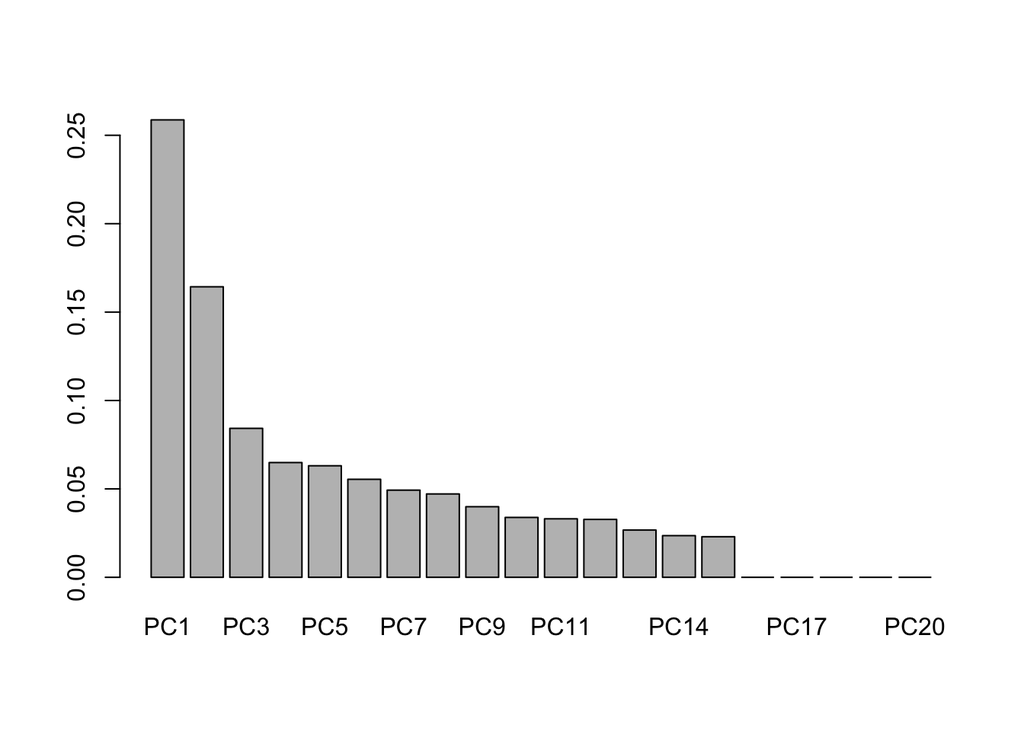

```r
res.list<-list()

for (i in 1:length(log2.HRC.plus.mm4H.rpkm.speLength.Q[,1])){
batch.fit<-lm(log2.HRC.plus.mm4H.rpkm.speLength.Q[i,]~as.factor(batch))
res.list[[i]]<-as.data.frame(t(batch.fit$residuals))
}
batch.fit.res<-rbind_all(res.list)
pc<-prcomp(t(na.omit(batch.fit.res)),center = T,scale = T)
#pc<-prcomp(batch.fit$residuals[1:13,],center = T,scale = T)

barplot((pc$sdev)^2/sum((pc$sdev)^2), names.arg =  colnames(pc$x))
```

```r
spec<-substring(rownames(pc$x),1,1)
temp.data<-as.data.frame(cbind(melt(pc$x),pc$x[,1],spec,batch))
```

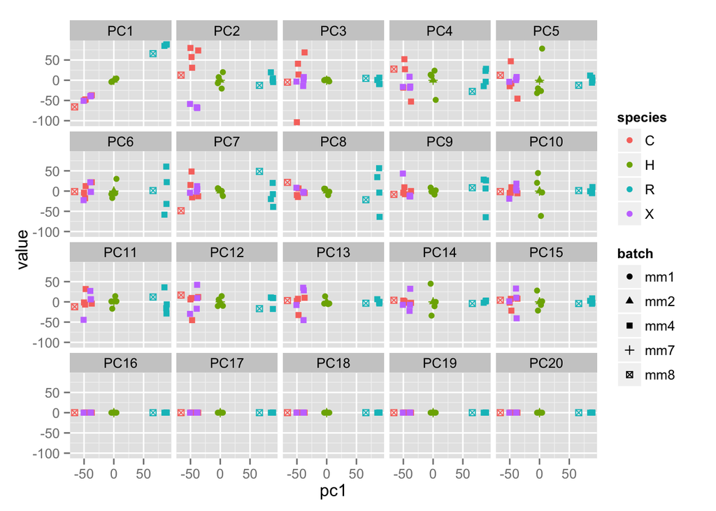

```r
names(temp.data)<-c("ID","PC","value","pc1","species","batch")

temp.data %>% ggplot(aes(x=pc1,y=value))+geom_point(aes(color = species, shape=batch))+facet_wrap(~PC)
```

protect main effect and regress out batch (fix effect)

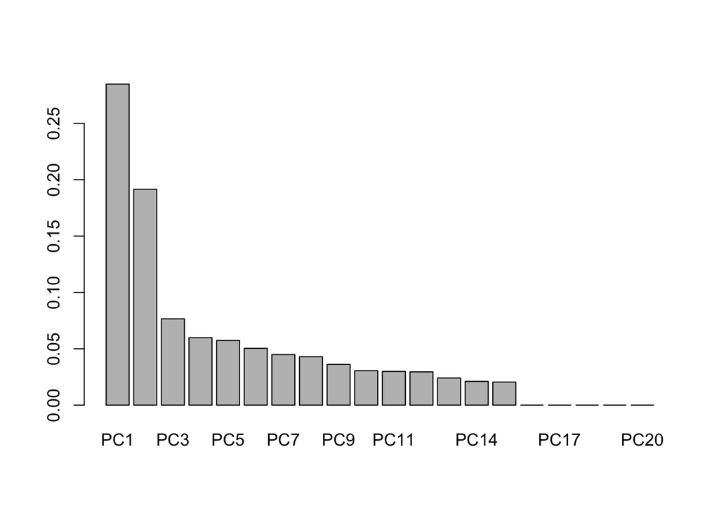

```r
spec<-substring(colnames(log2.HRC.plus.mm4H.rpkm.speLength.Q),1,1)
spec[17:20]<-c("H","H","H","H")
spec.design <- model.matrix(~ 0+spec)

res.list<-list()
intercept<-c()
beta1<-c()
beta2<-c()
for (i in 1:length(log2.HRC.plus.mm4H.rpkm.speLength.Q[,1])){
batch.fit<-lm(log2.HRC.plus.mm4H.rpkm.speLength.Q[i,]~as.factor(spec)+as.factor(batch))
res.list[[i]]<-as.data.frame(t(batch.fit$residuals))
intercept[i]<-batch.fit$coefficients[1]
beta1[i]<-batch.fit$coefficients[2]
beta2[i]<-batch.fit$coefficients[3]

                          }

batch.fit.res<-rbind_all(res.list)
batch.removed<-batch.fit.res+intercept+beta1 %*% t(spec.design[,2])+beta2 %*% t(spec.design[,3])

pc<-prcomp(t(na.omit(batch.removed)),center = T,scale = T)
#pc<-prcomp(batch.fit$residuals[1:13,],center = T,scale = T)

barplot((pc$sdev)^2/sum((pc$sdev)^2), names.arg =  colnames(pc$x))
```

```r
spec<-substring(rownames(pc$x),1,1)
temp.data<-as.data.frame(cbind(melt(pc$x),pc$x[,1],spec,batch))
```

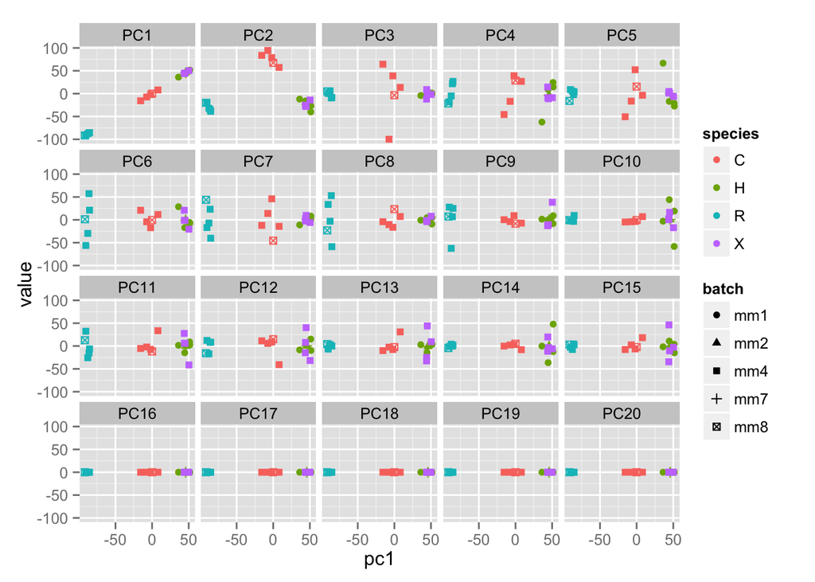

```r
names(temp.data)<-c("ID","PC","value","pc1","species","batch")

temp.data %>% ggplot(aes(x=pc1,y=value))+geom_point(aes(color = species, shape=batch))+facet_wrap(~PC)
```

limma remove batch effect

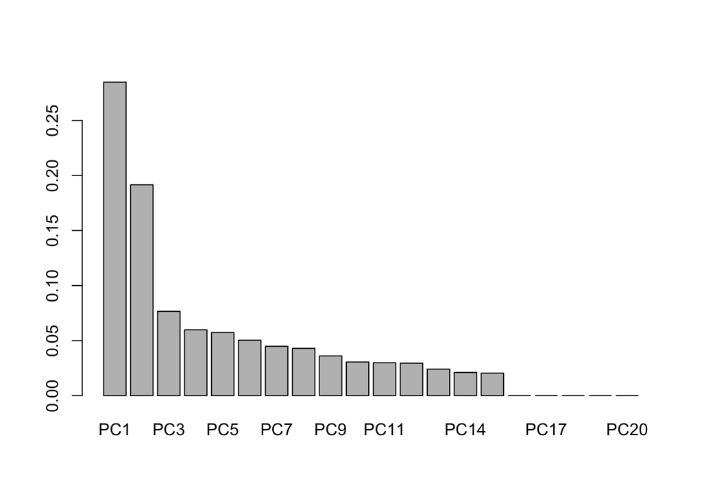

```r
spec<-substring(colnames(log2.HRC.plus.mm4H.rpkm.speLength.Q),1,1)
spec[17:20]<-c("H","H","H","H")
spec.design <- model.matrix(~ 0+spec)
#batch.removed.limma.full<-removeBatchEffect(log2.HRC.plus.mm4H.rpkm.speLength.Q,batch = as.factor(batch))
batch.removed.limma.full<-removeBatchEffect(log2.HRC.plus.mm4H.rpkm.speLength.Q,batch = as.factor(batch),design = spec.design)


pc<-prcomp(t(na.omit(batch.removed.limma.full)),center = T,scale = T)
#pc<-prcomp(batch.fit$residuals[1:13,],center = T,scale = T)

barplot((pc$sdev)^2/sum((pc$sdev)^2), names.arg =  colnames(pc$x))
```

```r
spec<-substring(rownames(pc$x),1,1)
temp.data<-as.data.frame(cbind(melt(pc$x),pc$x[,1],spec,batch))
```

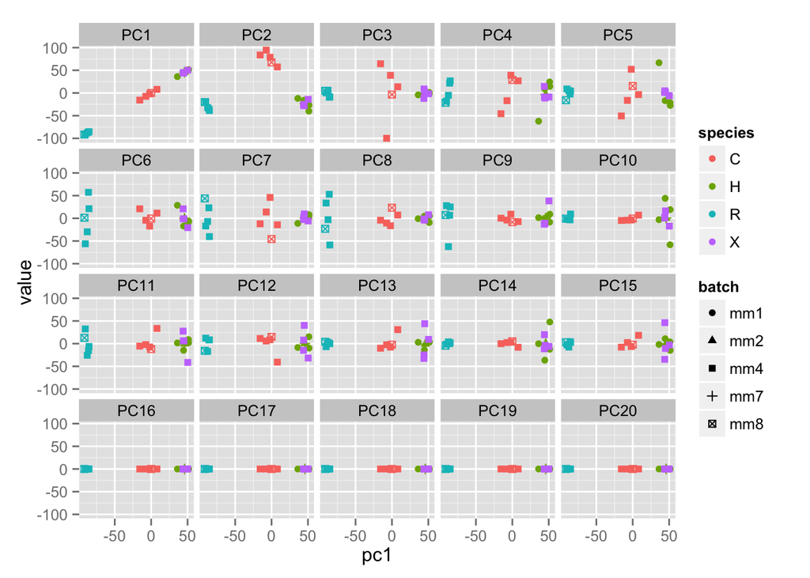

```r
names(temp.data)<-c("ID","PC","value","pc1","species","batch")

temp.data %>% ggplot(aes(x=pc1,y=value))+geom_point(aes(color = species, shape=batch))+facet_wrap(~PC)
```